# Assignment5

Bhagyarathi Raman

2/25/2022

```r
rm(list=ls())
```

```r
ToyotaPrices <- read.csv("/Users/bhagyarathivivek/downloads/ToyotaPrices/ToyotaPrices.csv")
head(ToyotaPrices)
```

```
##   Id Price Age_08_04 Mfg_Month Mfg_Year    KM HP Automatic   cc Doors Cylinders
## 1  1 13500        23        10     2002 46986 90         0 2000     3         4
## 2  2 13750        23        10     2002 72937 90         0 2000     3         4
## 3  3 13950        24         9     2002 41711 90         0 2000     3         4
## 4  4 14950        26         7     2002 48000 90         0 2000     3         4
## 5  5 13750        30         3     2002 38500 90         0 2000     3         4
## 6  6 12950        32         1     2002 61000 90         0 2000     3         4
##   Gears Quarterly_Tax Weight Mfr_Guarantee BOVAG_Guarantee Guarantee_Period ABS
## 1     5           210   1165             0               1                3   1
## 2     5           210   1165             0               1                3   1
## 3     5           210   1165             1               1                3   1
## 4     5           210   1165             1               1                3   1
## 5     5           210   1170             1               1                3   1
## 6     5           210   1170             0               1                3   1
##   Airbag_1 Airbag_2 Airco Automatic_airco Boardcomputer CD_Player Central_Lock
```

[output cut: 20 more lines]

Subset the data as with Price, Mfg_Year, KM, Automatic, Weight, ABS, and Tow_Bar.

```r
sp<- subset(ToyotaPrices, select = c(Price,Mfg_Year,KM, Automatic, Weight,ABS,Tow_Bar))
```

Convert categorical variables to factor type with ( yes, no ) levels.

```r
sp$Automatic=factor(sp$Automatic)
levels(sp$Automatic)=c("NO","YES")
#NULL
sp$ABS=factor(sp$ABS)
levels(sp$ABS)=c("NO","YES")
sp$Tow_Bar=factor(sp$Tow_Bar)
levels(sp$Tow_Bar)=c ("NO","YES")
```

If KM is less than 500, convert the value to missing.

```r
sp$KM[sp$KM<500]<-NA
```

Remove all the NA from the dataset. This will eliminate the need to tell each command to remove NA before executing.

```r
sp=na.omit(sp)
```

```r
summary(sp)
```

```
##      Price          Mfg_Year          KM         Automatic      Weight
##  Min.   : 4350   Min.   :1998   Min.   :  1500   NO :1345   Min.   :1000
##  1st Qu.: 8450   1st Qu.:1998   1st Qu.: 43426   YES:  80   1st Qu.:1040
##  Median : 9900   Median :1999   Median : 63792              Median :1065
##  Mean   :10675   Mean   :2000   Mean   : 69062              Mean   :1072
##  3rd Qu.:11900   3rd Qu.:2001   3rd Qu.: 87358              3rd Qu.:1085
##  Max.   :31275   Max.   :2004   Max.   :243000              Max.   :1615
##   ABS       Tow_Bar
##  NO : 267   NO :1027
##  YES:1158   YES: 398
##
##
##
##
```

Scatterplot Matrix

Obtain a scatterplot matrix of Price, vs all the other variables. Put all factors variables first. Make Price the last variable. Discuss the plot. Suggest how to improve the plot.

```r
library(GGally)
```

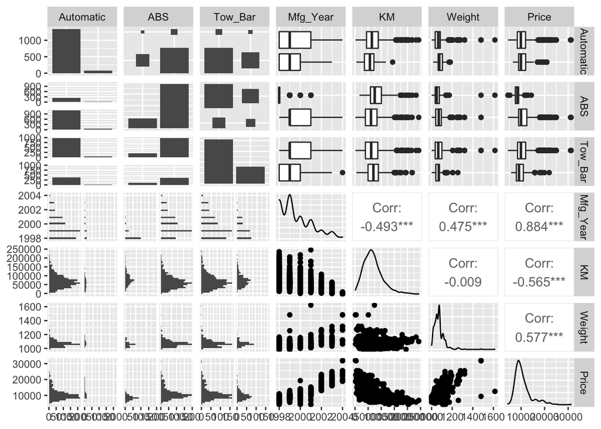

```r
#load(ggplot2)
ggpairs(sp, columns= c("Automatic",
                       "ABS",
                       "Tow_Bar",
                       "Mfg_Year",
                       "KM",
                       "Weight","Price"))
```

Scatterplot matrix with factor information

Obtain a scatterplot matrix of Price, vs Tow_Bar, KM, Mfg_Year, and Weight with the points colored by the levels of Tow_Bar. Make Price the last variable. Discuss the plot. Does it appear that the relation between Price and KM is the same or different for cars with or without a tow bar? I.e., are there any clear relationships visible that appear to be different for groups of cars with or without a tow bar?

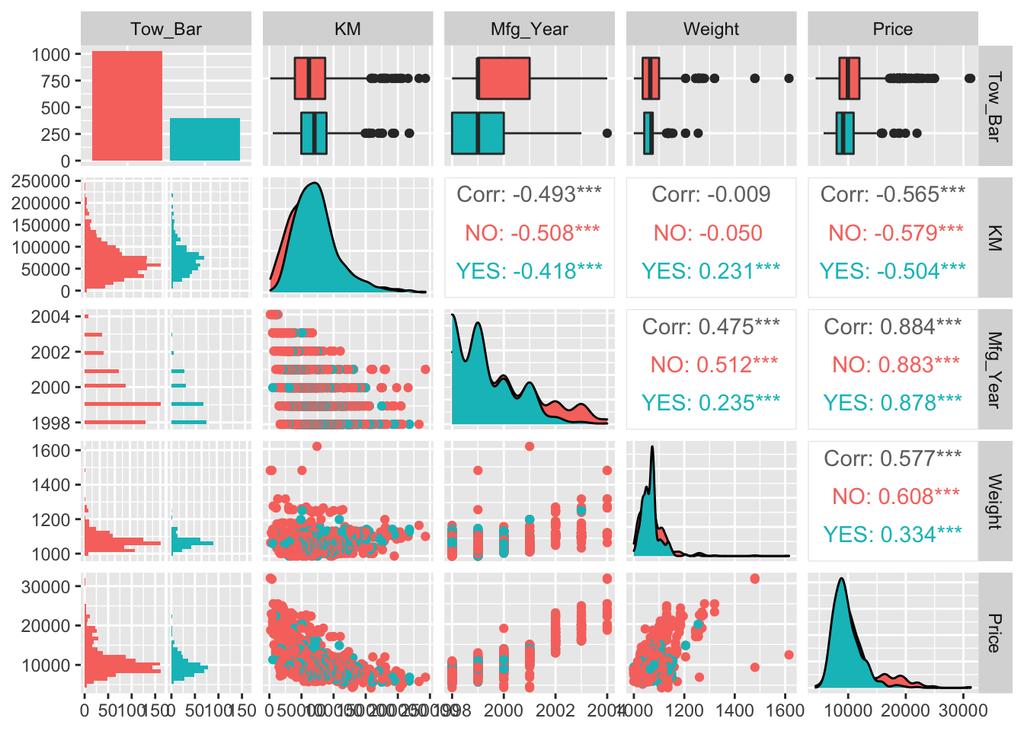

```r
library(GGally)
ggpairs(sp, columns= c("Tow_Bar",
                       "KM",
                       "Mfg_Year",
                       "Weight",
                       "Price"),
mapping=aes(colour=Tow_Bar))
```

Scatterplot matrix with factor information and fitted line

Add a smoother to the above scatterplot matrix. Discuss the information revealed by the smoother lines.

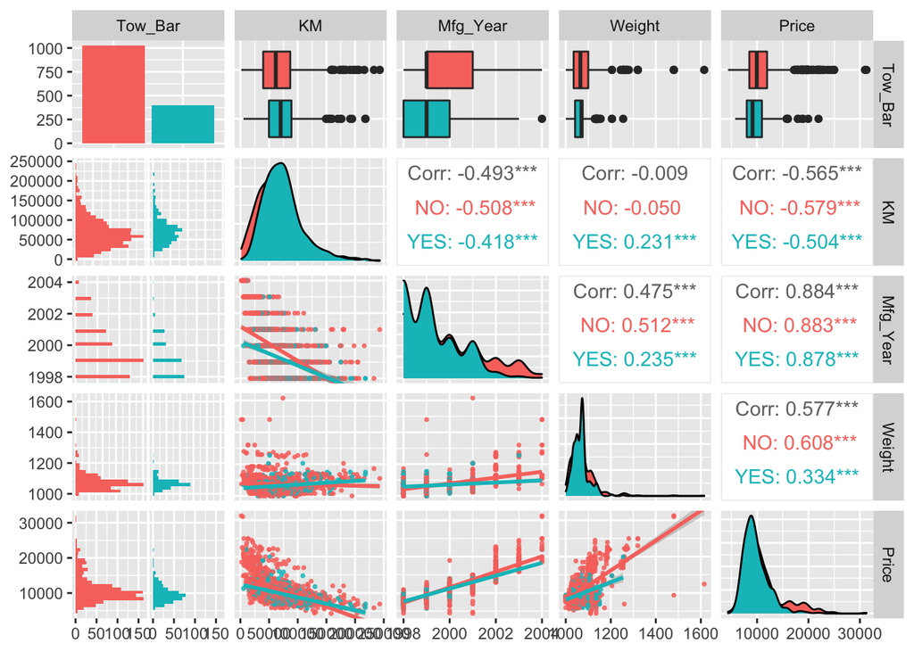

```r
library(GGally)
ggpairs(sp, columns= c("Tow_Bar",
                       "KM",
                       "Mfg_Year",
                       "Weight",
                       "Price"),
mapping=aes(colour=Tow_Bar),
lower=list(continuous=wrap("smooth",alpha= 0.8, size=0.6)))
```

Multiple regression model

We use linear regression models to explore how the price of a car is related to the manufacturing year, kilometers and weight for cars accounting for the options abs breaks, automatic transmission, and tow bar. Save the fit to g1.

Model g1: Price=β0+β1Mfg_Year+β2KM+β3Weight+β4ABS+β5Automatic+β6Tow_Bar+ϵ Produce the summary table for g1. Discuss the residuals, the standard error, the degrees of freedom, R2, and adjusted R2.

```r
g1 <- lm(Price ~ Mfg_Year + KM + Weight+ ABS+Automatic+Tow_Bar, sp)
summary(g1)
```

```
##
## Call:
## lm(formula = Price ~ Mfg_Year + KM + Weight + ABS + Automatic +
##     Tow_Bar, data = sp)
##
## Residuals:
##      Min       1Q   Median       3Q      Max
## -10495.6   -726.1     -3.7    722.9   6624.5
##
## Coefficients:
##                Estimate Std. Error t value Pr(>|t|)
## (Intercept)  -3.013e+06  6.975e+04 -43.201   <2e-16 ***
## Mfg_Year      1.503e+03  3.512e+01  42.808   <2e-16 ***
## KM           -2.357e-02  1.159e-03 -20.333   <2e-16 ***
## Weight        1.858e+01  8.303e-01  22.384   <2e-16 ***
## ABSYES       -2.187e+02  9.976e+01  -2.192   0.0285 *
## AutomaticYES  2.954e+02  1.559e+02   1.895   0.0583 .
## Tow_BarYES   -1.156e+02  8.002e+01  -1.445   0.1487
## ---
## Signif. codes:  0 '***' 0.001 '**' 0.01 '*' 0.05 '.' 0.1 ' ' 1
##
## Residual standard error: 1334 on 1418 degrees of freedom
## Multiple R-squared:  0.8585, Adjusted R-squared:  0.8579
## F-statistic:  1434 on 6 and 1418 DF,  p-value: < 2.2e-16
```

Show that R2 is equal to the square of the correlation between Price and the fitted values.

```r
c(summary(g1)$r.square, cor(g1$fitted.values, sp$Price)^2)
```

```
## [1] 0.8584889 0.8584889
```

Residual plot

Obtain the residual plot with fitted values.

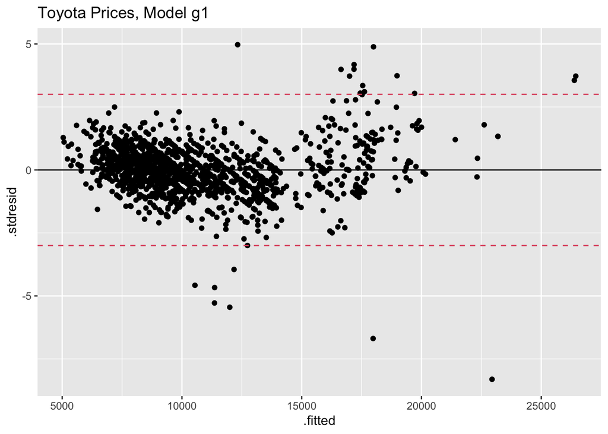

```r
ggplot(g1) +
  aes(x=.fitted, y=.stdresid) +
  geom_point() +
  geom_hline(yintercept=c(-3, 0, 3), color=c(2,1,2), linetype=c(2,1,2))+
  labs(title="Toyota Prices, Model g1")
```

Residuals vs explanatory variables

Plot the residuals of model g1 versus all the explanatory variables. Which variable plot(s) is (are) there a pattern that indicates that the model g1 does not express those variables adequately?

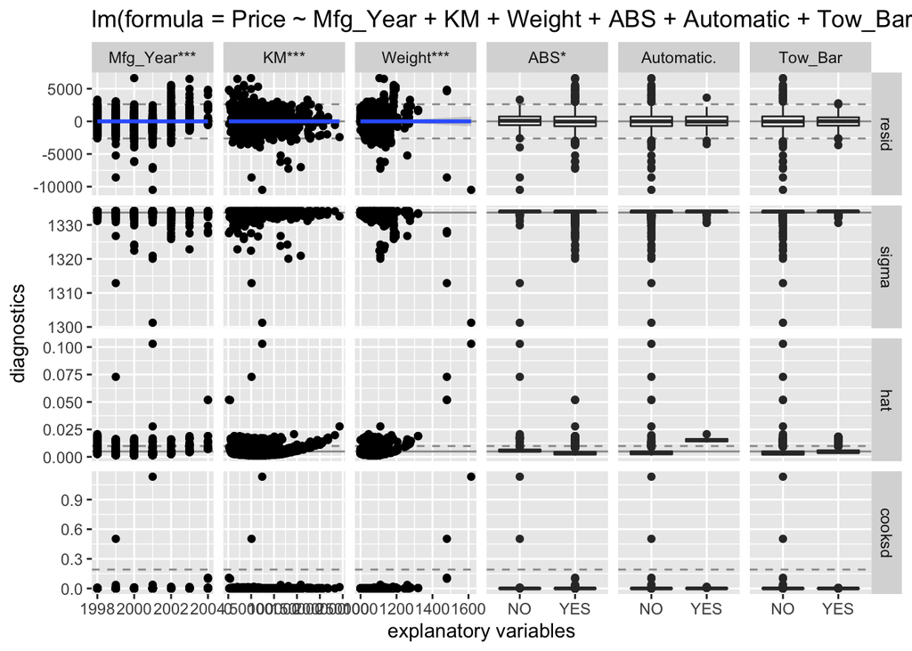

```r
ggnostic(g1)
```

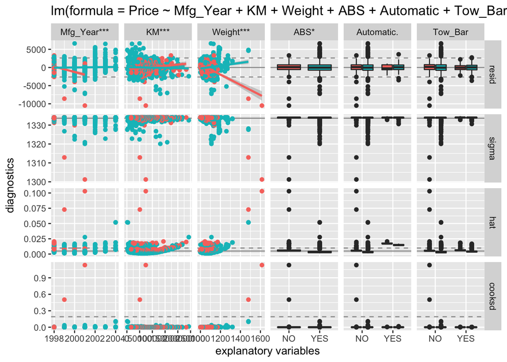

```r
ggnostic(
  g1,
  mapping = aes(color = ABS))
```

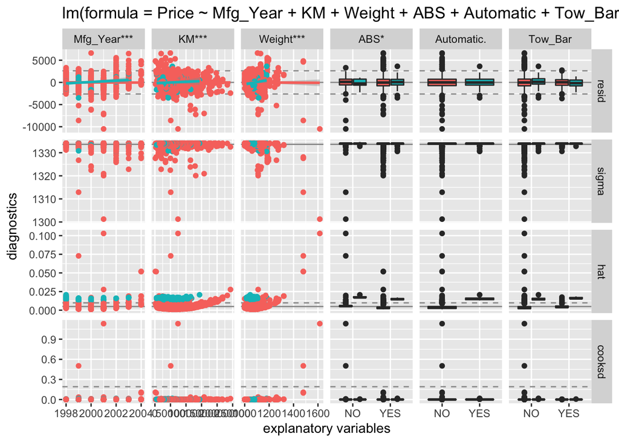

```r
ggnostic(
  g1,
  mapping = aes(color = Automatic))
```

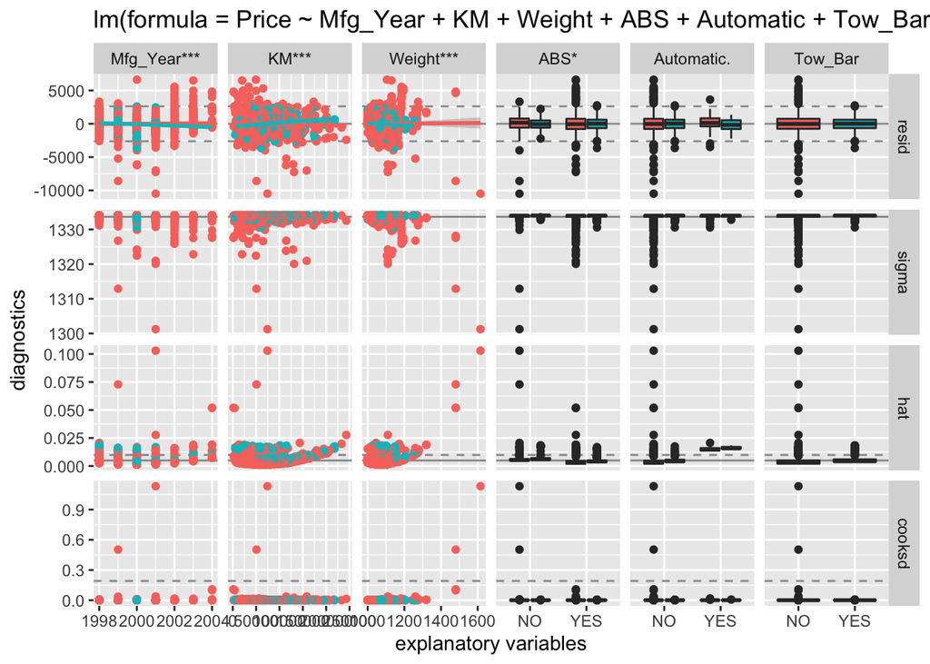

```r
ggnostic(
  g1,
  mapping = aes(color = Tow_Bar))
```

Comparing a big and a small model

Fit a model without the options variables (categorical variables). Call the model g2.

```r
g2 <- lm(Price~Mfg_Year+KM+Weight, sp)
summary(g2)
```

```
##
## Call:
## lm(formula = Price ~ Mfg_Year + KM + Weight, data = sp)
##
## Residuals:
##      Min       1Q   Median       3Q      Max
## -10479.3   -738.1    -27.6    741.6   6588.7
##
## Coefficients:
##               Estimate Std. Error t value Pr(>|t|)
## (Intercept) -2.953e+06  6.368e+04  -46.38   <2e-16 ***
## Mfg_Year     1.473e+03  3.206e+01   45.95   <2e-16 ***
## KM          -2.403e-02  1.146e-03  -20.96   <2e-16 ***
## Weight       1.899e+01  8.190e-01   23.19   <2e-16 ***
## ---
## Signif. codes:  0 '***' 0.001 '**' 0.01 '*' 0.05 '.' 0.1 ' ' 1
##
## Residual standard error: 1337 on 1421 degrees of freedom
## Multiple R-squared:  0.8575, Adjusted R-squared:  0.8572
## F-statistic:  2849 on 3 and 1421 DF,  p-value: < 2.2e-16
```

Compare the adjusted R2 values from models g1 and g2. Interpret the result.

```r
c(summary(g1)$adj.r.squared, summary(g2)$adj.r.squared)
```

```
## [1] 0.8578902 0.8571551
```

Model g2 is as good as g1